# Experiments for Requirement Gathering Phase

In this notebook, I will perform a number of experiments on the data gathered from those who took our survey. We asked 18 questions dealing with demographics, sleep health, and their relationship with music in order to gauge how well our platform would be received.

##### Limitations

Most of our participants are college students, so the data will largely be restricted to a younger demographic. While this may limit our reach at first, I believe that younger people (especially those in college) are generally more willing to try new things, so there should not be much of an issue with the data being skewed in this manner. Also, while our sample size isn't massive, it is large enough to get a feel for where the general population which we interviewed stand as a whole.

I also noticed a few people did not answer each question. I believe that we should have marked certain questions as must be answered because having entries who only partially participated may also undermine the validity of our data. As a counter-measure, I shall remove non-compliant respondents from studies which they may skew on a case-by-case basis.

```python
import pandas as pd
import numpy as np
import matplotlib.pyplot as plt
import seaborn as sns
import re
from collections import Counter
from wordcloud import WordCloud
from PIL import Image
```

##### Loading the Data

The data, obtained from Google Forms, is stored in a comma-separated value (CSV) file, which we can simply read into this notebook.

```python
full_set = pd.read_csv("Mindful Music.csv")
all_entries = pd.DataFrame(full_set)
```

Now, we'll move on to our first experiment.

### Stress Management and Alcohol

Firstly, we are going to examine respondent's reported alcohol use against how well they estimate they can handle stress. We believe that our platform could serve as an effective alternative to heavy drinking, as the negative effects of alcohol eclipse any perceived solace from stress.

```python
headings = all_entries.columns.values.tolist()[1:] # the timestamps are unimportant for our purposes
alcohol_question = headings[5]
stress_question = headings[8]
```

```python
alcohol_column = all_entries[alcohol_question]
stress_column = all_entries[stress_question]
first_ex = pd.DataFrame({alcohol_question: alcohol_column, stress_question: stress_column})
```

We now have all data relative to the alcohol question and the stress management question sequestered into a new DataFrame object, on which we will now operate. As I mentioned before, participants who failed to answer a relevant question should have their input nullified for the applicable experiment.

```python
for index, row in first_ex.iterrows():
    if not row[alcohol_question] or not row[stress_question]:
        first_ex.drop(index, inplace=True)
```

```python
print(first_ex.size)
```

```
188
```

We have verified that incomplete listings have been removed; now let's plot the data and see what insights we can muster.

```python
sns.set()
```

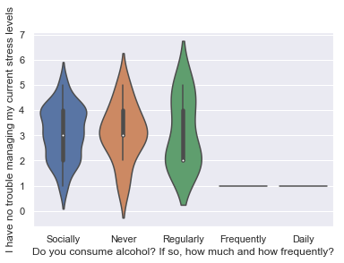

```python
sns.violinplot(x=first_ex[alcohol_question], y=first_ex[stress_question])
```

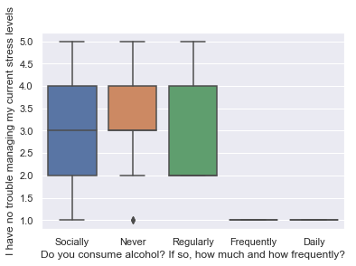

```python
sns.boxplot(x=first_ex[alcohol_question], y=first_ex[stress_question])
```

I think a study into smoking/other drug use would have been interesting, but we simply do not have enough data to continue that way.

### Interest Levels among college students

Since college students were the most heavily interviewed group in our survey, I am now going to examine which majors were most interested. First, the data we received for majors was poorly formatted, but we can fix that here.

```python
occupation_question = headings[2]
major_question = headings[3]
interest_question = headings[-1]
```

```python
occupation_column = all_entries[occupation_question]
major_column = all_entries[major_question]
interest_column = all_entries[interest_question]
second_ex = pd.DataFrame({occupation_question: occupation_column,
                          major_question: major_column,
                          interest_question: interest_column})
```

Now, we will clean all non-students and students with incomplete data from the table.

```python
for index, row in second_ex.iterrows():
    # for some reason, the sheet we got had the major column
    # set to NaN if there was no major selected
    if type(row[major_question]) is not str:
        second_ex.drop(index, inplace=True)
    else:
        majors = [s.strip().lower() for s in re.split('/|and|;|&', row[major_question])]
        # more than one major necessitates the inputs being broken up
        if len(majors) > 1:
            second_ex.drop(index, inplace=True)
            offset = second_ex.size / 3
            for i in range(0, len(majors)):
                second_ex.loc[offset + i] = [row[occupation_question], majors[i], row[interest_question]]
        elif 'Csci' in majors:
            second_ex.drop(index, inplace=True)
            second_ex.loc[second_ex.size / 3] = [row[occupation_question], 'computer science', row[interest_question]]
```

```python
counter = Counter(second_ex[major_question])
# print(counter)
for index, row in second_ex.iterrows():
    if counter[row[major_question]] < 2:
        second_ex.drop(index, inplace=True)
```

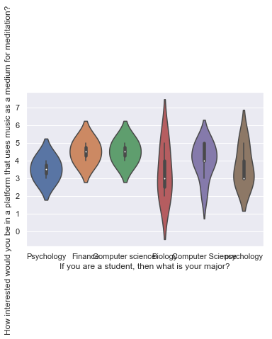

```python
sns.violinplot(x=second_ex[major_question], y=second_ex[interest_question])
```

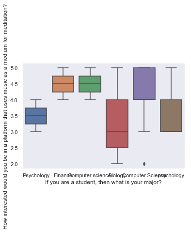

```python
sns.boxplot(x=second_ex[major_question], y=second_ex[interest_question])
```

We had to weed out majors that only had one respondent, as the plots became unreadable otherwise. The plots do show substantial interest in the platform across a few majors, though, so we know that the interest is there. In order to better illustrate the interest figures, see the table below for a breakdown of those who recorded a 4 or 5.

```python
high_interest_by_major = {}
for index, row in second_ex.iterrows():
    if row[interest_question] > 3:
        if row[major_question] not in list(high_interest_by_major.keys()):
            high_interest_by_major[row[major_question]] = 1
        else:
            high_interest_by_major[row[major_question]] += 1

high_interest_table = pd.DataFrame(high_interest_by_major, index=[0])
print(high_interest_table.to_string())
```

```
   Psychology  Finance  Computer science   Computer Science  Biology  psychology
0           1        2                  2                 7        1           1
```

### Relationship between interest levels and gender

This section is to measure the average interest levels among men and women. We are adhering to a binary approach to gender because there simply is not enough data on any other groups.

```python
gender_question = headings[1]
gender_column = all_entries[gender_question]
third_ex = pd.DataFrame({gender_question: gender_column, interest_question: interest_column})
```

```python
for index, row in third_ex.iterrows():
    if row[gender_question] not in ['Male', 'Female'] or int(row[interest_question]) not in range(1,6):
        third_ex.drop(index, inplace=True)
```

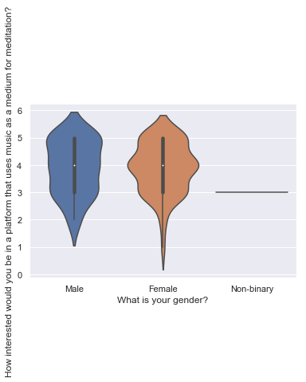

```python
sns.violinplot(x=gender_column, y=interest_column)
```

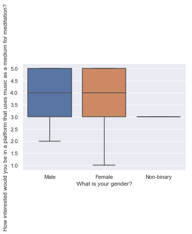

```python
sns.boxplot(x=gender_column, y=interest_column)
```

As shown above, men and women are roughly equal in terms of their interest. Men's responses are more evenly spread across the board, with women largely concentrated at a 4 out of 5. We think that a unisex approach to design will likely be important, as men and women alike would be the target audience.

### Relationship between age and interest level

Lastly, we will examine the relationship between age ranges and reported interest level in the platform. Because our analysis is showing that men and women are roughly equally interested across the board, age ranges may give us some more data on how to target our design.

```python
age_question = headings[0]
age_column = all_entries[age_question]
fourth_ex = pd.DataFrame({age_question: age_column, interest_question: interest_column})
```

```python
for index, row in fourth_ex.iterrows():
    if type(row[age_question]) is not str or row[interest_question] not in range(1,6):
        fourth_ex.drop(index, inplace=True)
```

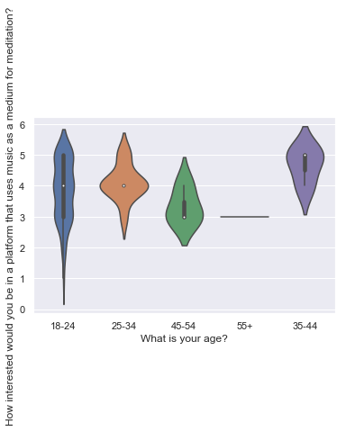

```python
sns.violinplot(x=fourth_ex[age_question], y=fourth_ex[interest_question])
```

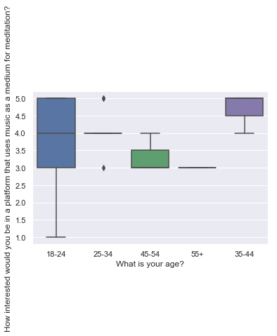

```python
sns.boxplot(x=fourth_ex[age_question], y=fourth_ex[interest_question])
```

### What people say about meditation and music therapy

We also asked questions about people's relationships with meditation and/or music therapy. These questions allowed for users to enter freehand responses, which we will look at here.

I am opting to assemble a wordcloud for each question to see which words were used the most often; that way, we can get the best idea of what the larger perceptions of these two things are.

##### Meditation

```python
meditation_question = headings[-3]
meditation_column = all_entries[meditation_question]
fifth_ex = pd.DataFrame({meditation_question: meditation_column})
```

```python
words = []
for index, row in fifth_ex.iterrows():
    if type(row[meditation_question]) is str and len(row[meditation_question]) > 2:
        words.append(row[meditation_question])
```

```python
cloud = WordCloud(contour_color='white', colormap='winter')
cloud.generate("".join(words))
```

```
<wordcloud.wordcloud.WordCloud at 0x1a27678748>
```

```python
cloud.to_file("meditation-map.png")
```

```
<wordcloud.wordcloud.WordCloud at 0x1a27678748>
```

This is the result

[figure not shown]

##### Music Therapy

```python
mt_question = headings[-2]
mt_column = all_entries[mt_question]
sixth_ex = pd.DataFrame({mt_question: mt_column})
```

```python
words = []
for index, row in sixth_ex.iterrows():
    if type(row[mt_question]) is str and len(row[mt_question]) > 2:
        words.append(row[mt_question])
```

```python
cloud2 = WordCloud(contour_color='white', colormap='winter')
cloud2.generate("".join(words))
```

```
<wordcloud.wordcloud.WordCloud at 0x1a27676470>
```

```python
cloud2.to_file("mt-map.png")
```

```
<wordcloud.wordcloud.WordCloud at 0x1a27676470>
```

This is the result

[figure not shown]